# Dr.H

Mo’men Mohamed

March 11, 2019

Loading the important package

```r
library(lavaan) ; library(GPArotation) ; library(knitr) ; library(knitLatex) ; library(readxl) ; library(ggplot2) ;library(tidyr) ; library(dplyr) ; library(magrittr) ; library(car) ; library(psych) ; library(kableExtra) ; library(semPlot) ; library(semTools)
```

Reading the data and importing it

```r
big<-read_excel(path = "./data sets/big5.xlsx")
```

Looking at the data structure

```r
str(big)
```

```
## Classes 'tbl_df', 'tbl' and 'data.frame':    225 obs. of  33 variables:
##  $ serial: num  1 2 3 4 5 6 7 8 9 10 ...
##  $ Age   : num  18 19 18 19 18 22 22 18 23 19 ...
##  $ Sex   : num  1 1 1 1 1 1 1 1 1 1 ...
##  $ E1    : num  3 3 3 2 2 4 1 2 3 2 ...
##  $ E2    : num  3 2 4 3 3 4 4 4 3 1 ...
##  $ E3    : num  2 4 3 2 2 4 4 3 3 2 ...
##  $ E4    : num  3 2 4 2 3 4 4 4 3 4 ...
##  $ E6    : num  4 4 1 3 3 4 1 4 3 2 ...
##  $ E7    : num  3 3 4 3 3 4 4 2 2 4 ...
##  $ N1    : num  2 2 4 4 3 2 4 1 2 2 ...
##  $ N2    : num  1 2 1 2 2 3 2 1 2 1 ...
##  $ N3    : num  1 2 2 2 2 2 1 1 2 1 ...
##  $ N5    : num  3 2 1 2 4 3 4 1 3 4 ...
##  $ N8    : num  4 2 1 2 2 3 4 1 2 2 ...
```

[output cut: 19 more lines]

We need to remove “serial” and convert “sex” to factor Male and female

```r
big<-big[,-1]

big$Sex<-factor(x = big$Sex,levels = c(1,2),labels = c("male","female"))

kable(head(big),format = "markdown")
```

| Age | Sex | E1 | E2 | E3 | E4 | E6 | E7 | N1 | N2 | N3 | N5 | N8 | N9 | A1 | A2 | A3 | A4 | A5 | A6 | O2 | O3 | O4 | O5 | O6 | O8 | C3 | C4 | C5 | C6 | … |
| --- | --- | --- | --- | --- | --- | --- | --- | --- | --- | --- | --- | --- | --- | --- | --- | --- | --- | --- | --- | --- | --- | --- | --- | --- | --- | --- | --- | --- | --- | --- |
| 18 | male | 3 | 3 | 2 | 3 | 4 | 3 | 2 | 1 | 1 | 3 | 4 | 1 | 3 | 3 | 4 | 3 | 3 | 3 | 3 | 3 | 1 | 2 | 3 | 4 | 4 | 2 | 3 | 4 | … |
| 19 | male | 3 | 2 | 4 | 2 | 4 | 3 | 2 | 2 | 2 | 2 | 2 | 2 | 3 | 3 | 2 | 3 | 2 | 3 | 2 | 1 | 2 | 3 | 4 | 3 | 2 | 4 | 3 | 2 | … |
| 18 | male | 3 | 4 | 3 | 4 | 1 | 4 | 4 | 1 | 2 | 1 | 1 | 2 | 4 | 2 | 3 | 3 | 3 | 3 | 4 | 3 | 4 | 4 | 3 | 3 | 4 | 4 | 2 | 3 | … |
| 19 | male | 2 | 3 | 2 | 2 | 3 | 3 | 4 | 2 | 2 | 2 | 2 | 2 | 3 | 4 | 4 | 4 | 4 | 4 | 3 | 1 | 3 | 3 | 3 | 3 | 3 | 3 | 3 | 2 | … |
| 18 | male | 2 | 3 | 2 | 3 | 3 | 3 | 3 | 2 | 2 | 4 | 2 | 1 | 3 | 2 | 3 | 4 | 4 | 2 | 4 | 2 | 3 | 4 | 3 | 4 | 2 | 4 | 4 | 3 | … |
| 22 | male | 4 | 4 | 4 | 4 | 4 | 4 | 2 | 3 | 2 | 3 | 3 | 2 | 4 | 4 | 3 | 4 | 4 | 4 | 3 | 2 | 4 | 3 | 3 | 4 | 3 | 4 | 4 | 4 | … |

Now lets look at some summary for the data over all

```r
summary(big) #Foor accurecy, out bound items and missing data
```

```
##       Age            Sex            E1              E2
##  Min.   :17.00   male  :114   Min.   :1.000   Min.   :1.000
##  1st Qu.:18.00   female:111   1st Qu.:2.000   1st Qu.:2.000
##  Median :19.00                Median :2.000   Median :3.000
##  Mean   :20.21                Mean   :2.551   Mean   :2.538
##  3rd Qu.:20.00                3rd Qu.:3.000   3rd Qu.:3.000
##  Max.   :40.00                Max.   :4.000   Max.   :4.000
##        E3              E4              E6              E7
##  Min.   :1.000   Min.   :1.000   Min.   :1.000   Min.   :1.000
##  1st Qu.:2.000   1st Qu.:2.000   1st Qu.:3.000   1st Qu.:2.000
##  Median :2.000   Median :3.000   Median :3.000   Median :3.000
##  Mean   :2.569   Mean   :2.667   Mean   :3.196   Mean   :2.889
##  3rd Qu.:3.000   3rd Qu.:3.000   3rd Qu.:4.000   3rd Qu.:4.000
##  Max.   :4.000   Max.   :4.000   Max.   :4.000   Max.   :4.000
##        N1              N2              N3             N5
##  Min.   :1.000   Min.   :1.000   Min.   :1.00   Min.   :1.000
##  1st Qu.:2.000   1st Qu.:1.000   1st Qu.:1.00   1st Qu.:2.000
##  Median :2.000   Median :2.000   Median :2.00   Median :2.000
##  Mean   :2.356   Mean   :1.942   Mean   :1.96   Mean   :2.302
##  3rd Qu.:3.000   3rd Qu.:2.000   3rd Qu.:2.00   3rd Qu.:3.000
##  Max.   :4.000   Max.   :4.000   Max.   :4.00   Max.   :4.000
##        N8              N9              A1              A2
##  Min.   :1.000   Min.   :1.000   Min.   :1.000   Min.   :1.000
##  1st Qu.:1.000   1st Qu.:1.000   1st Qu.:3.000   1st Qu.:2.000
##  Median :2.000   Median :2.000   Median :4.000   Median :3.000
##  Mean   :2.013   Mean   :1.973   Mean   :3.293   Mean   :2.893
##  3rd Qu.:3.000   3rd Qu.:2.000   3rd Qu.:4.000   3rd Qu.:4.000
##  Max.   :4.000   Max.   :4.000   Max.   :4.000   Max.   :4.000
##        A3              A4              A5              A6
##  Min.   :1.000   Min.   :1.000   Min.   :1.000   Min.   :1.000
##  1st Qu.:2.000   1st Qu.:3.000   1st Qu.:3.000   1st Qu.:2.000
##  Median :3.000   Median :4.000   Median :3.000   Median :3.000
##  Mean   :3.142   Mean   :3.493   Mean   :3.342   Mean   :3.138
##  3rd Qu.:4.000   3rd Qu.:4.000   3rd Qu.:4.000   3rd Qu.:4.000
##  Max.   :4.000   Max.   :4.000   Max.   :4.000   Max.   :4.000
##        O2              O3              O4              O5
##  Min.   :1.000   Min.   :1.000   Min.   :1.000   Min.   :1.000
##  1st Qu.:2.000   1st Qu.:2.000   1st Qu.:2.000   1st Qu.:2.000
##  Median :3.000   Median :3.000   Median :3.000   Median :3.000
##  Mean   :2.769   Mean   :2.533   Mean   :2.693   Mean   :3.062
##  3rd Qu.:4.000   3rd Qu.:3.000   3rd Qu.:4.000   3rd Qu.:4.000
##  Max.   :4.000   Max.   :4.000   Max.   :4.000   Max.   :4.000
##        O6             O8              C3              C4
##  Min.   :1.00   Min.   :1.000   Min.   :1.000   Min.   :1.000
##  1st Qu.:2.00   1st Qu.:3.000   1st Qu.:2.000   1st Qu.:2.000
##  Median :3.00   Median :4.000   Median :3.000   Median :3.000
##  Mean   :2.88   Mean   :3.338   Mean   :2.782   Mean   :3.071
##  3rd Qu.:4.00   3rd Qu.:4.000   3rd Qu.:4.000   3rd Qu.:4.000
##  Max.   :4.00   Max.   :4.000   Max.   :4.000   Max.   :4.000
##        C5             C6              C7             C8
##  Min.   :1.00   Min.   :1.000   Min.   :1.00   Min.   :1.000
##  1st Qu.:2.00   1st Qu.:2.000   1st Qu.:2.00   1st Qu.:3.000
##  Median :3.00   Median :3.000   Median :3.00   Median :3.000
##  Mean   :3.04   Mean   :2.844   Mean   :2.84   Mean   :2.973
##  3rd Qu.:4.00   3rd Qu.:4.000   3rd Qu.:4.00   3rd Qu.:4.000
##  Max.   :4.00   Max.   :4.000   Max.   :4.00   Max.   :4.000
```

```r
outidx<-which(big$Age>qnorm(p = .99,mean = mean(big$Age),sd = sd(big$Age))) # testing outlier over Propapility 99%

kable(big[outidx,],format = "markdown")
```

| Age | Sex | E1 | E2 | E3 | E4 | E6 | E7 | N1 | N2 | N3 | N5 | N8 | N9 | A1 | A2 | A3 | A4 | A5 | A6 | O2 | O3 | O4 | O5 | O6 | O8 | C3 | C4 | C5 | C6 | … |
| --- | --- | --- | --- | --- | --- | --- | --- | --- | --- | --- | --- | --- | --- | --- | --- | --- | --- | --- | --- | --- | --- | --- | --- | --- | --- | --- | --- | --- | --- | --- |
| 40 | male | 2 | 1 | 2 | 3 | 4 | 2 | 1 | 1 | 1 | 2 | 2 | 1 | 3 | 3 | 3 | 4 | 3 | 2 | 2 | 2 | 2 | 2 | 2 | 2 | 3 | 3 | 3 | 3 | … |
| 40 | male | 3 | 2 | 4 | 4 | 4 | 4 | 2 | 2 | 1 | 2 | 1 | 1 | 4 | 2 | 4 | 4 | 4 | 4 | 3 | 4 | 4 | 4 | 4 | 3 | 4 | 4 | 4 | 4 | … |
| 37 | male | 4 | 3 | 4 | 2 | 4 | 2 | 1 | 2 | 1 | 1 | 1 | 1 | 3 | 4 | 3 | 3 | 3 | 3 | 3 | 4 | 4 | 4 | 3 | 4 | 4 | 4 | 4 | 3 | … |
| 34 | male | 2 | 1 | 1 | 2 | 3 | 2 | 2 | 1 | 2 | 2 | 1 | 3 | 4 | 4 | 4 | 4 | 4 | 4 | 4 | 4 | 4 | 4 | 4 | 4 | 4 | 4 | 4 | 4 | … |
| 32 | male | 3 | 2 | 3 | 3 | 4 | 3 | 3 | 2 | 1 | 2 | 2 | 1 | 2 | 1 | 2 | 3 | 3 | 2 | 2 | 2 | 2 | 2 | 3 | 3 | 2 | 3 | 3 | 2 | … |
| 32 | female | 3 | 2 | 2 | 2 | 4 | 3 | 3 | 2 | 2 | 2 | 2 | 1 | 3 | 3 | 3 | 3 | 3 | 3 | 2 | 2 | 2 | 2 | 2 | 3 | 2 | 3 | 3 | 3 | … |
| 37 | female | 3 | 1 | 2 | 4 | 4 | 3 | 2 | 3 | 1 | 2 | 1 | 1 | 4 | 3 | 4 | 4 | 4 | 4 | 4 | 1 | 4 | 4 | 4 | 4 | 4 | 4 | 4 | 4 | … |
| 33 | female | 2 | 2 | 2 | 2 | 3 | 2 | 3 | 3 | 2 | 2 | 1 | 2 | 4 | 2 | 4 | 4 | 4 | 4 | 3 | 3 | 3 | 3 | 2 | 4 | 4 | 3 | 3 | 4 | … |

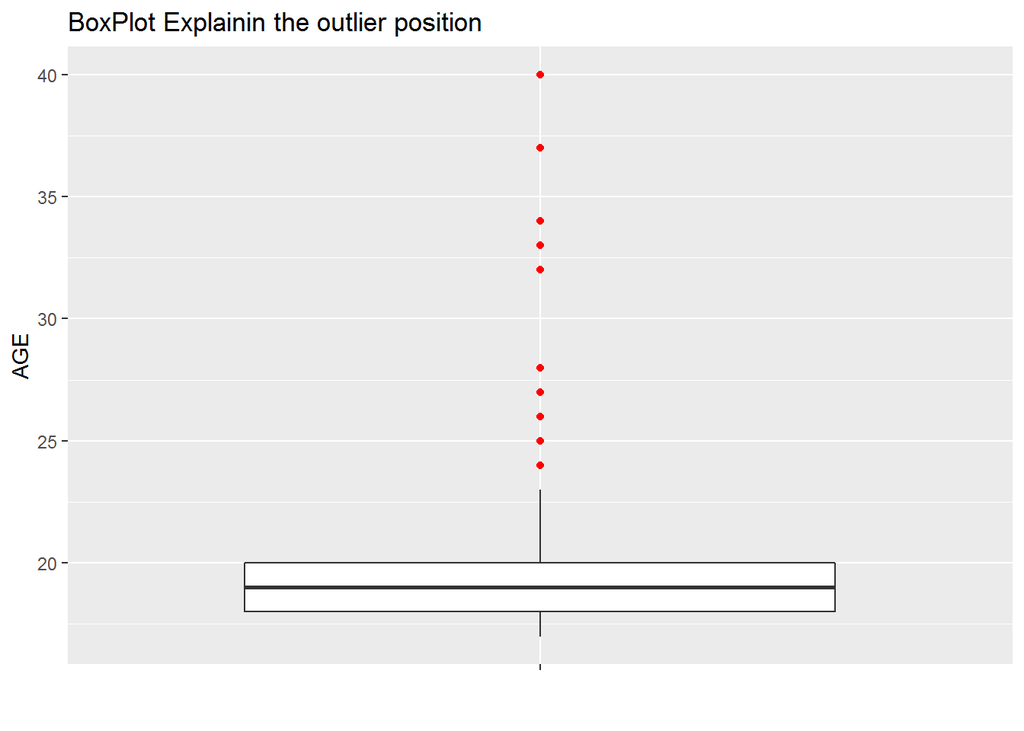

```r
big%>%ggplot(aes(x = "",y = Age))+geom_boxplot(outlier.color = "red")+
        labs(title = "BoxPlot Explainin the outlier position")+
        xlab("")+ylab("AGE")
```

Great , the there is no out of bound items or missing data , and the number of males and females is all most equal

but unfortunately we have some outlier data records in the variable of age

I will remove all about 25 to confirm that all of my sample are in period of early adulthood

I Will remove these outlier

```r
big<-big[!big$Age>25,]
```

The normality and linearity assumption is critical for Factor analysis and SEM , So, Lets test it

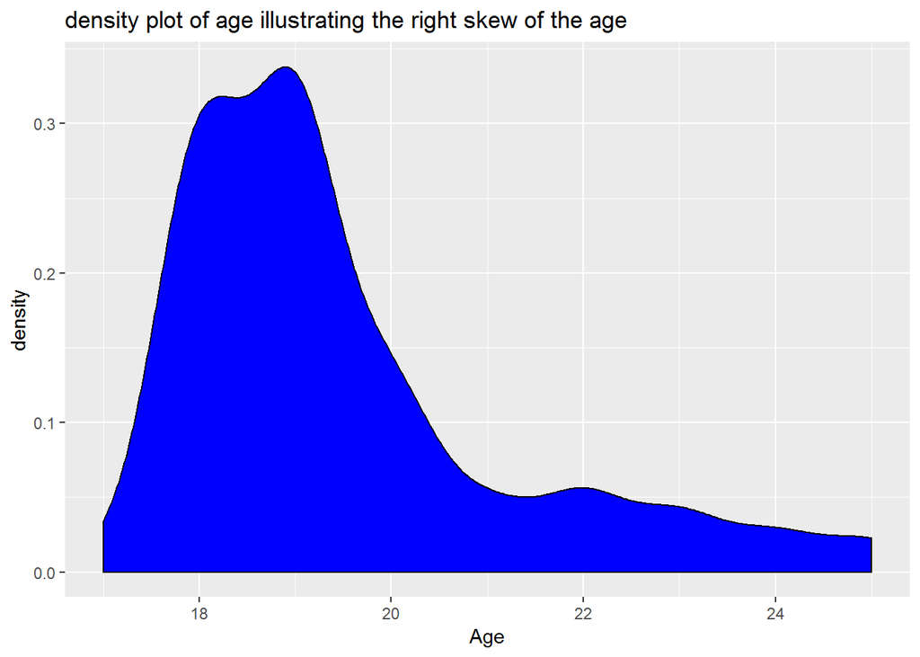

```r
ggplot(data = big,aes(Age))+geom_density(fill="blue")+labs(title = "density plot of age illustrating the right skew of the age") #Normality inspection of age
```

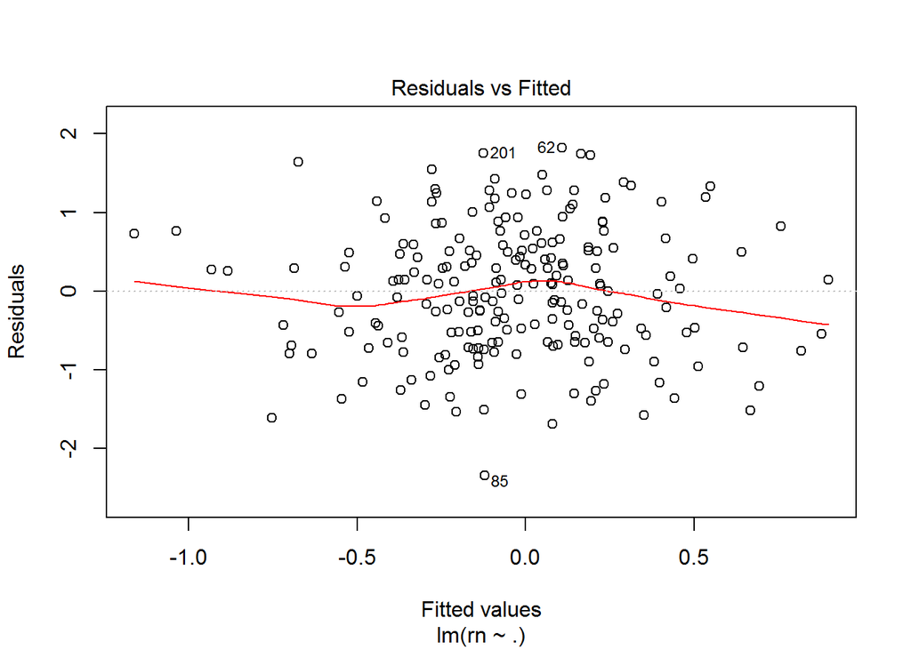

```r
set.seed(0124)
rn<-rnorm(n = nrow(big))
lm<-lm(rn~.,data = big[,-c(1,2)])

plot(lm,1) #Homogeniety
```

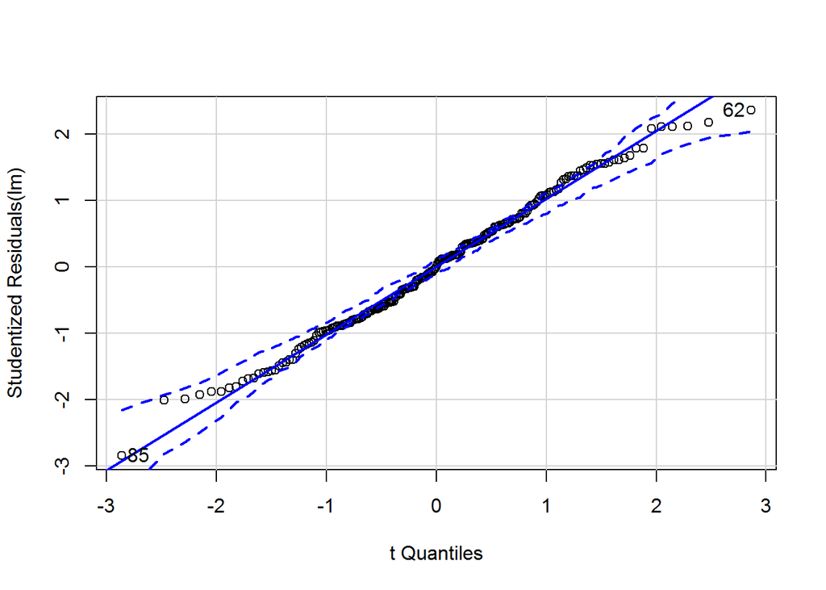

```
## [1] 62 85
```

```r
qqPlot(lm) # Normality and linearity
```

From The QQplot we can see that we can assume the normality and linearity of the data

Now It is the time to dive more in our data

I need to classify sample age into to grouped

1- Early adults => > 20 y

2- Late Adolescents => < 20 y

```r
big$age_group<-sapply(big$Age,function(x){
        if(x>20){paste("Adult")}
        else{paste("adol")}
})

kable(head(big),format = "markdown")
```

| Age | Sex | E1 | E2 | E3 | E4 | E6 | E7 | N1 | N2 | N3 | N5 | N8 | N9 | A1 | A2 | A3 | A4 | A5 | A6 | O2 | O3 | O4 | O5 | O6 | O8 | C3 | C4 | C5 | C6 | … |
| --- | --- | --- | --- | --- | --- | --- | --- | --- | --- | --- | --- | --- | --- | --- | --- | --- | --- | --- | --- | --- | --- | --- | --- | --- | --- | --- | --- | --- | --- | --- |
| 18 | male | 3 | 3 | 2 | 3 | 4 | 3 | 2 | 1 | 1 | 3 | 4 | 1 | 3 | 3 | 4 | 3 | 3 | 3 | 3 | 3 | 1 | 2 | 3 | 4 | 4 | 2 | 3 | 4 | … |
| 19 | male | 3 | 2 | 4 | 2 | 4 | 3 | 2 | 2 | 2 | 2 | 2 | 2 | 3 | 3 | 2 | 3 | 2 | 3 | 2 | 1 | 2 | 3 | 4 | 3 | 2 | 4 | 3 | 2 | … |
| 18 | male | 3 | 4 | 3 | 4 | 1 | 4 | 4 | 1 | 2 | 1 | 1 | 2 | 4 | 2 | 3 | 3 | 3 | 3 | 4 | 3 | 4 | 4 | 3 | 3 | 4 | 4 | 2 | 3 | … |
| 19 | male | 2 | 3 | 2 | 2 | 3 | 3 | 4 | 2 | 2 | 2 | 2 | 2 | 3 | 4 | 4 | 4 | 4 | 4 | 3 | 1 | 3 | 3 | 3 | 3 | 3 | 3 | 3 | 2 | … |
| 18 | male | 2 | 3 | 2 | 3 | 3 | 3 | 3 | 2 | 2 | 4 | 2 | 1 | 3 | 2 | 3 | 4 | 4 | 2 | 4 | 2 | 3 | 4 | 3 | 4 | 2 | 4 | 4 | 3 | … |
| 22 | male | 4 | 4 | 4 | 4 | 4 | 4 | 2 | 3 | 2 | 3 | 3 | 2 | 4 | 4 | 3 | 4 | 4 | 4 | 3 | 2 | 4 | 3 | 3 | 4 | 3 | 4 | 4 | 4 | … |

Now lets illustrate the frequency with probabilities of gender in each age class due to decide if we can consider the age as a group for conducting the measurement variance proving procedures

```r
tab<-table(big$Sex,big$age_group)

kable(round(prop.table(tab,margin = 1),2),format = "markdown",caption = "propapility table of age and sex groups ")
```

|  | adol | Adult |
| --- | --- | --- |
| male | 0.78 | 0.22 |
| female | 0.83 | 0.17 |

As we see , we can’t assume that the age group is a valid group as the sex is not uniformly distributed in it !!

But we still need to confirm that the two sex have the same mean of age

we will prove that using independent t-test

```r
with(big,
     bartlett.test(Age~Sex)) # the variance is equal between group
```

```
##
##  Bartlett test of homogeneity of variances
##
## data:  Age by Sex
## Bartlett's K-squared = 3.104, df = 1, p-value = 0.0781
```

```r
with(big,
     t.test(formula=Age~Sex,alternative="two.sided",conf.level=.95,paired=F))
```

```
##
##  Welch Two Sample t-test
##
## data:  Age by Sex
## t = -0.21163, df = 203.01, p-value = 0.8326
## alternative hypothesis: true difference in means is not equal to 0
## 95 percent confidence interval:
##  -0.5349413  0.4312376
## sample estimates:
##   mean in group male mean in group female
##             19.48148             19.53333
```

Congrats!! the two groups has the same mean of age with p.value 0.8326 and equal in variance with P, Value =0.0781

The following steps include conducting EFA and CFA

Lets start with EFA:

Firstly lets test the assumptions : **Additivity** , ** sample adequacy **

```r
#Additivity

corr<-cor(x = big[,-c(1,2,ncol(big))],method = "p")

kable(corr,digits = 2,format = "markdown") #correlation table
```

|  | E1 | E2 | E3 | E4 | E6 | E7 | N1 | N2 | N3 | N5 | N8 | N9 | A1 | A2 | A3 | A4 | A5 | A6 | O2 | O3 | O4 | O5 | O6 | O8 | C3 | C4 | C5 | C6 | C7 | … |
| --- | --- | --- | --- | --- | --- | --- | --- | --- | --- | --- | --- | --- | --- | --- | --- | --- | --- | --- | --- | --- | --- | --- | --- | --- | --- | --- | --- | --- | --- | --- |
| E1 | 1.00 | 0.38 | 0.55 | 0.43 | 0.43 | 0.36 | -0.11 | -0.08 | -0.20 | -0.17 | -0.02 | -0.19 | 0.02 | 0.09 | 0.08 | 0.10 | 0.18 | 0.18 | 0.08 | 0.05 | 0.01 | 0.14 | 0.11 | 0.23 | 0.10 | 0.16 | 0.18 | 0.06 | 0.11 | … |
| E2 | 0.38 | 1.00 | 0.43 | 0.27 | 0.34 | 0.39 | -0.09 | -0.19 | -0.27 | -0.13 | -0.04 | -0.27 | 0.05 | 0.07 | 0.12 | 0.14 | 0.24 | 0.20 | 0.13 | 0.07 | 0.19 | 0.07 | 0.11 | 0.33 | 0.09 | 0.15 | 0.26 | 0.06 | 0.14 | … |
| E3 | 0.55 | 0.43 | 1.00 | 0.34 | 0.42 | 0.47 | -0.12 | -0.21 | -0.32 | -0.13 | -0.07 | -0.22 | 0.10 | 0.07 | 0.06 | 0.13 | 0.25 | 0.18 | 0.16 | 0.14 | 0.22 | 0.20 | 0.20 | 0.27 | 0.24 | 0.24 | 0.18 | 0.16 | 0.27 | … |
| E4 | 0.43 | 0.27 | 0.34 | 1.00 | 0.26 | 0.38 | -0.07 | -0.11 | -0.19 | -0.02 | 0.01 | -0.09 | -0.01 | 0.15 | 0.13 | 0.16 | 0.23 | 0.22 | 0.12 | 0.13 | 0.16 | 0.19 | 0.11 | 0.19 | 0.09 | 0.23 | 0.11 | 0.03 | 0.08 | … |
| E6 | 0.43 | 0.34 | 0.42 | 0.26 | 1.00 | 0.35 | -0.15 | -0.31 | -0.44 | -0.33 | -0.15 | -0.48 | -0.05 | 0.09 | -0.02 | 0.07 | 0.07 | 0.09 | -0.09 | 0.06 | -0.03 | 0.09 | 0.09 | 0.16 | 0.01 | 0.06 | 0.16 | 0.07 | 0.04 | … |
| E7 | 0.36 | 0.39 | 0.47 | 0.38 | 0.35 | 1.00 | -0.06 | -0.22 | -0.33 | -0.14 | -0.04 | -0.26 | 0.10 | 0.07 | 0.13 | 0.20 | 0.29 | 0.21 | 0.18 | 0.11 | 0.13 | 0.21 | 0.17 | 0.30 | 0.17 | 0.32 | 0.29 | 0.00 | 0.17 | … |
| N1 | -0.11 | -0.09 | -0.12 | -0.07 | -0.15 | -0.06 | 1.00 | 0.40 | 0.34 | 0.49 | 0.33 | 0.16 | 0.03 | 0.08 | 0.01 | 0.04 | 0.05 | 0.00 | -0.11 | 0.03 | -0.10 | -0.10 | -0.10 | 0.02 | -0.03 | -0.11 | -0.09 | -0.14 | -0.09 | … |
| N2 | -0.08 | -0.19 | -0.21 | -0.11 | -0.31 | -0.22 | 0.40 | 1.00 | 0.56 | 0.44 | 0.28 | 0.40 | 0.10 | 0.04 | 0.08 | 0.00 | 0.07 | 0.09 | 0.01 | -0.03 | -0.03 | -0.11 | -0.08 | -0.07 | 0.01 | -0.14 | -0.04 | -0.01 | -0.03 | … |
| N3 | -0.20 | -0.27 | -0.32 | -0.19 | -0.44 | -0.33 | 0.34 | 0.56 | 1.00 | 0.36 | 0.28 | 0.51 | 0.05 | 0.08 | 0.12 | 0.03 | 0.02 | 0.01 | 0.02 | -0.02 | -0.02 | -0.08 | -0.03 | -0.14 | 0.07 | -0.18 | -0.08 | 0.02 | -0.08 | … |
| N5 | -0.17 | -0.13 | -0.13 | -0.02 | -0.33 | -0.14 | 0.49 | 0.44 | 0.36 | 1.00 | 0.51 | 0.36 | -0.03 | -0.03 | 0.03 | -0.04 | 0.00 | -0.07 | -0.14 | -0.01 | -0.01 | -0.17 | -0.14 | -0.02 | 0.00 | -0.11 | -0.10 | -0.11 | -0.08 | … |
| N8 | -0.02 | -0.04 | -0.07 | 0.01 | -0.15 | -0.04 | 0.33 | 0.28 | 0.28 | 0.51 | 1.00 | 0.30 | -0.08 | 0.03 | 0.04 | 0.00 | 0.07 | -0.02 | -0.10 | -0.08 | -0.02 | -0.13 | -0.04 | 0.03 | 0.06 | -0.14 | -0.11 | -0.11 | -0.18 | … |
| N9 | -0.19 | -0.27 | -0.22 | -0.09 | -0.48 | -0.26 | 0.16 | 0.40 | 0.51 | 0.36 | 0.30 | 1.00 | 0.04 | 0.01 | 0.10 | 0.02 | -0.04 | -0.06 | 0.02 | 0.01 | -0.01 | -0.10 | -0.05 | -0.08 | 0.05 | -0.11 | -0.14 | -0.08 | -0.05 | … |
| A1 | 0.02 | 0.05 | 0.10 | -0.01 | -0.05 | 0.10 | 0.03 | 0.10 | 0.05 | -0.03 | -0.08 | 0.04 | 1.00 | 0.33 | 0.39 | 0.36 | 0.33 | 0.36 | 0.13 | 0.25 | 0.20 | 0.16 | 0.00 | 0.18 | 0.20 | 0.16 | 0.15 | 0.32 | 0.35 | … |
| A2 | 0.09 | 0.07 | 0.07 | 0.15 | 0.09 | 0.07 | 0.08 | 0.04 | 0.08 | -0.03 | 0.03 | 0.01 | 0.33 | 1.00 | 0.47 | 0.31 | 0.34 | 0.36 | 0.07 | 0.08 | 0.12 | 0.16 | 0.14 | 0.14 | 0.13 | 0.10 | 0.10 | 0.11 | 0.17 | … |
| A3 | 0.08 | 0.12 | 0.06 | 0.13 | -0.02 | 0.13 | 0.01 | 0.08 | 0.12 | 0.03 | 0.04 | 0.10 | 0.39 | 0.47 | 1.00 | 0.42 | 0.47 | 0.36 | 0.12 | 0.19 | 0.18 | 0.16 | 0.12 | 0.25 | 0.24 | 0.07 | 0.15 | 0.20 | 0.26 | … |
| A4 | 0.10 | 0.14 | 0.13 | 0.16 | 0.07 | 0.20 | 0.04 | 0.00 | 0.03 | -0.04 | 0.00 | 0.02 | 0.36 | 0.31 | 0.42 | 1.00 | 0.52 | 0.40 | 0.07 | 0.20 | 0.22 | 0.24 | 0.16 | 0.24 | 0.17 | 0.18 | 0.22 | 0.17 | 0.26 | … |
| A5 | 0.18 | 0.24 | 0.25 | 0.23 | 0.07 | 0.29 | 0.05 | 0.07 | 0.02 | 0.00 | 0.07 | -0.04 | 0.33 | 0.34 | 0.47 | 0.52 | 1.00 | 0.49 | 0.23 | 0.18 | 0.30 | 0.22 | 0.17 | 0.28 | 0.30 | 0.34 | 0.36 | 0.24 | 0.36 | … |
| A6 | 0.18 | 0.20 | 0.18 | 0.22 | 0.09 | 0.21 | 0.00 | 0.09 | 0.01 | -0.07 | -0.02 | -0.06 | 0.36 | 0.36 | 0.36 | 0.40 | 0.49 | 1.00 | 0.13 | 0.19 | 0.32 | 0.21 | 0.18 | 0.19 | 0.22 | 0.29 | 0.36 | 0.36 | 0.27 | … |
| O2 | 0.08 | 0.13 | 0.16 | 0.12 | -0.09 | 0.18 | -0.11 | 0.01 | 0.02 | -0.14 | -0.10 | 0.02 | 0.13 | 0.07 | 0.12 | 0.07 | 0.23 | 0.13 | 1.00 | 0.41 | 0.47 | 0.47 | 0.34 | 0.08 | 0.29 | 0.31 | 0.26 | 0.20 | 0.30 | … |
| O3 | 0.05 | 0.07 | 0.14 | 0.13 | 0.06 | 0.11 | 0.03 | -0.03 | -0.02 | -0.01 | -0.08 | 0.01 | 0.25 | 0.08 | 0.19 | 0.20 | 0.18 | 0.19 | 0.41 | 1.00 | 0.29 | 0.35 | 0.22 | 0.20 | 0.23 | 0.13 | 0.09 | 0.18 | 0.22 | … |
| O4 | 0.01 | 0.19 | 0.22 | 0.16 | -0.03 | 0.13 | -0.10 | -0.03 | -0.02 | -0.01 | -0.02 | -0.01 | 0.20 | 0.12 | 0.18 | 0.22 | 0.30 | 0.32 | 0.47 | 0.29 | 1.00 | 0.53 | 0.35 | 0.26 | 0.34 | 0.24 | 0.29 | 0.26 | 0.26 | … |
| O5 | 0.14 | 0.07 | 0.20 | 0.19 | 0.09 | 0.21 | -0.10 | -0.11 | -0.08 | -0.17 | -0.13 | -0.10 | 0.16 | 0.16 | 0.16 | 0.24 | 0.22 | 0.21 | 0.47 | 0.35 | 0.53 | 1.00 | 0.35 | 0.29 | 0.22 | 0.23 | 0.28 | 0.19 | 0.30 | … |
| O6 | 0.11 | 0.11 | 0.20 | 0.11 | 0.09 | 0.17 | -0.10 | -0.08 | -0.03 | -0.14 | -0.04 | -0.05 | 0.00 | 0.14 | 0.12 | 0.16 | 0.17 | 0.18 | 0.34 | 0.22 | 0.35 | 0.35 | 1.00 | 0.25 | 0.37 | 0.27 | 0.26 | 0.29 | 0.28 | … |
| O8 | 0.23 | 0.33 | 0.27 | 0.19 | 0.16 | 0.30 | 0.02 | -0.07 | -0.14 | -0.02 | 0.03 | -0.08 | 0.18 | 0.14 | 0.25 | 0.24 | 0.28 | 0.19 | 0.08 | 0.20 | 0.26 | 0.29 | 0.25 | 1.00 | 0.19 | 0.23 | 0.28 | 0.18 | 0.20 | … |
| C3 | 0.10 | 0.09 | 0.24 | 0.09 | 0.01 | 0.17 | -0.03 | 0.01 | 0.07 | 0.00 | 0.06 | 0.05 | 0.20 | 0.13 | 0.24 | 0.17 | 0.30 | 0.22 | 0.29 | 0.23 | 0.34 | 0.22 | 0.37 | 0.19 | 1.00 | 0.38 | 0.36 | 0.47 | 0.45 | … |
| C4 | 0.16 | 0.15 | 0.24 | 0.23 | 0.06 | 0.32 | -0.11 | -0.14 | -0.18 | -0.11 | -0.14 | -0.11 | 0.16 | 0.10 | 0.07 | 0.18 | 0.34 | 0.29 | 0.31 | 0.13 | 0.24 | 0.23 | 0.27 | 0.23 | 0.38 | 1.00 | 0.59 | 0.29 | 0.37 | … |
| C5 | 0.18 | 0.26 | 0.18 | 0.11 | 0.16 | 0.29 | -0.09 | -0.04 | -0.08 | -0.10 | -0.11 | -0.14 | 0.15 | 0.10 | 0.15 | 0.22 | 0.36 | 0.36 | 0.26 | 0.09 | 0.29 | 0.28 | 0.26 | 0.28 | 0.36 | 0.59 | 1.00 | 0.42 | 0.50 | … |
| C6 | 0.06 | 0.06 | 0.16 | 0.03 | 0.07 | 0.00 | -0.14 | -0.01 | 0.02 | -0.11 | -0.11 | -0.08 | 0.32 | 0.11 | 0.20 | 0.17 | 0.24 | 0.36 | 0.20 | 0.18 | 0.26 | 0.19 | 0.29 | 0.18 | 0.47 | 0.29 | 0.42 | 1.00 | 0.66 | … |
| C7 | 0.11 | 0.14 | 0.27 | 0.08 | 0.04 | 0.17 | -0.09 | -0.03 | -0.08 | -0.08 | -0.18 | -0.05 | 0.35 | 0.17 | 0.26 | 0.26 | 0.36 | 0.27 | 0.30 | 0.22 | 0.26 | 0.30 | 0.28 | 0.20 | 0.45 | 0.37 | 0.50 | 0.66 | 1.00 | … |
| C8 | 0.07 | 0.10 | 0.17 | 0.06 | 0.16 | 0.06 | -0.22 | -0.04 | -0.11 | -0.14 | -0.21 | -0.12 | 0.19 | 0.14 | 0.10 | 0.17 | 0.19 | 0.29 | 0.26 | 0.17 | 0.24 | 0.30 | 0.26 | 0.08 | 0.24 | 0.30 | 0.36 | 0.42 | 0.41 | … |

```r
corr%>%apply(MARGIN = 2,function(x){
        x<1&x>=abs(.9)
})%>%any() #Testing if there are a correlation over .9 between the items to avoid multicolinearity
```

```
## [1] FALSE
```

```r
#Enough correlation & Sample adequacy
cortest.bartlett(R = corr,n = nrow(big))$p.value#correlation bartelett test
```

```
## [1] 3.919203e-241
```

```r
KMO(corr)$MSA #Kaiser-Meyer-Olkin test
```

```
## [1] 0.8202394
```

since the assumptions have been met ( sig cor Bartlett and MSA >.8 and no additive ), Now we can run EFA

AS there are a priori theory which assume the presence of 5 factors on which the items load in unique way , there is no need to test the number of factors

but lets do it for fun !!

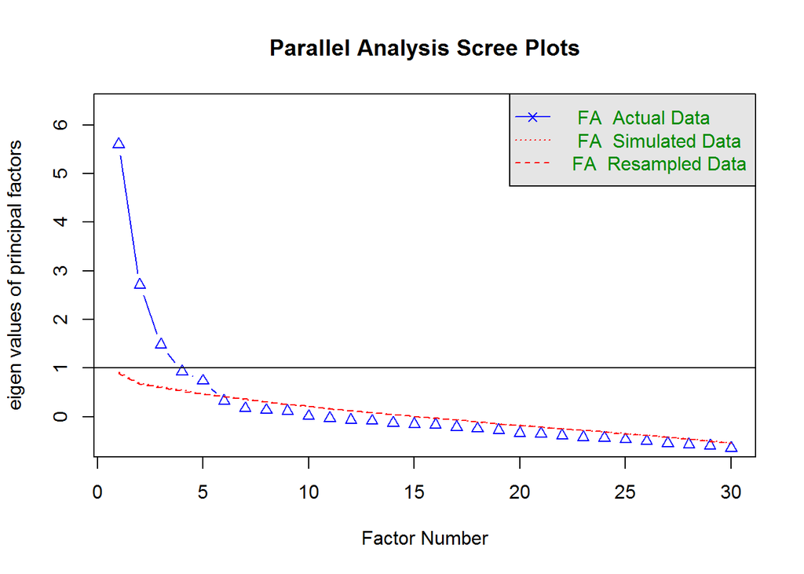

```
## Parallel analysis suggests that the number of factors =  5  and the number of components =  NA
```

```r
facno<-fa.parallel(x = big[,-c(1,2,ncol(big))],fm = "ml",fa = "fa") # as th data is normal , we choosed the Muximum likelihood method of Extraction
```

The parallel test suggest 5 factors !! agreeing with the theory , but for fancy lets look at scree plot & Kaiser Criterion

```r
(facno$fa.values>.7)%>%sum() #Kaiser criterion suggest 5 Factors !!
```

```
## [1] 5
```

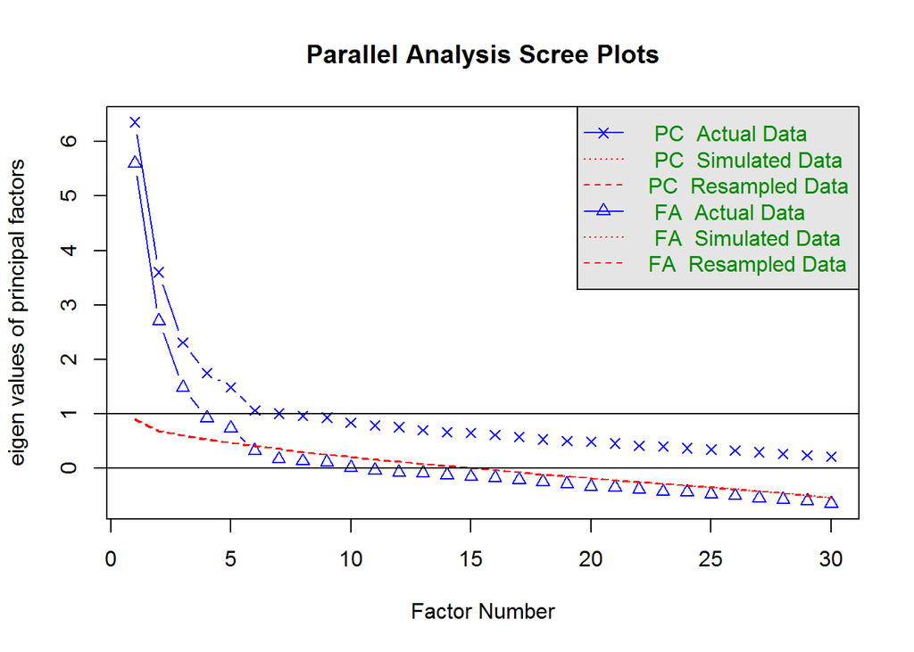

```r
plot(facno) #Scree plot Suggest 4 Factors with almost more one !!
```

As we see that Kaiser criterion of Eigen value suggest 5 factors and scree suggests 4 and almost one !! so we will consider those 5 !!

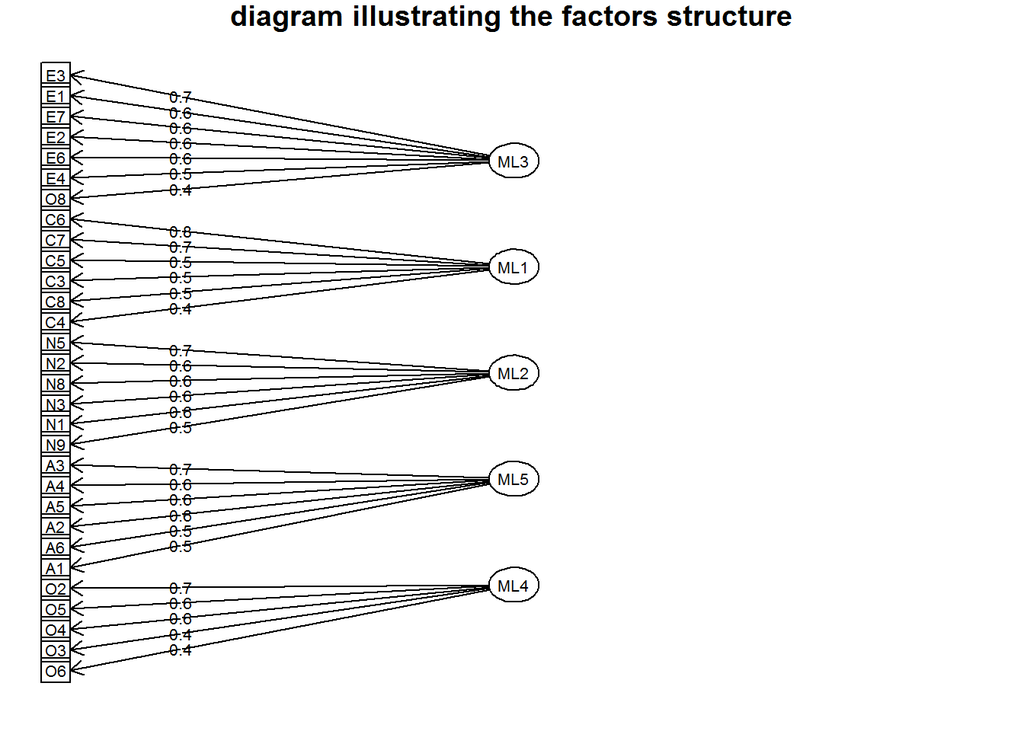

```r
fit<-fa(r = big[,-c(1,2,ncol(big))],nfactors = 5,rotate = "varimax",fm = "ml")
fa.diagram(fit,main = "diagram illustrating the factors structure")
```

The theory says that the factors are uncorrelated so , we used *Orthogonal (varimax)* rotation which prohibit the factors from correlations , and as the data is normal , so we used *maximum likelihood* Extraction method

```r
fit$loadings%>%matrix(ncol = 5,dimnames = list(c(names(big[,-c(1,2,ncol(big))])),paste0("F",1:5)))%>%kable(format = "markdown",digits = 3,caption = "Factor Items loading",row.names = T)
```

|  | F1 | F2 | F3 | F4 | F5 |
| --- | --- | --- | --- | --- | --- |
| E1 | 0.632 | 0.073 | -0.064 | 0.054 | 0.003 |
| E2 | 0.567 | 0.071 | -0.109 | 0.101 | 0.066 |
| E3 | 0.667 | 0.193 | -0.109 | 0.031 | 0.131 |
| E4 | 0.511 | -0.017 | 0.001 | 0.128 | 0.149 |
| E6 | 0.563 | 0.047 | -0.380 | 0.011 | -0.140 |
| E7 | 0.631 | 0.033 | -0.114 | 0.131 | 0.166 |
| N1 | -0.011 | -0.102 | 0.556 | 0.063 | -0.100 |
| N2 | -0.226 | 0.035 | 0.611 | 0.103 | -0.027 |
| N3 | -0.412 | 0.005 | 0.580 | 0.115 | 0.041 |
| N5 | -0.061 | -0.030 | 0.726 | -0.046 | -0.084 |
| N8 | 0.078 | -0.104 | 0.609 | -0.012 | -0.071 |
| N9 | -0.344 | -0.050 | 0.511 | 0.049 | 0.085 |
| A1 | -0.045 | 0.247 | -0.005 | 0.533 | 0.078 |
| A2 | 0.061 | 0.026 | 0.020 | 0.576 | 0.049 |
| A3 | 0.042 | 0.093 | 0.088 | 0.672 | 0.105 |
| A4 | 0.141 | 0.087 | 0.016 | 0.619 | 0.132 |
| A5 | 0.277 | 0.215 | 0.110 | 0.603 | 0.195 |
| A6 | 0.181 | 0.278 | 0.013 | 0.543 | 0.126 |
| O2 | 0.032 | 0.187 | -0.037 | 0.024 | 0.710 |
| O3 | 0.058 | 0.117 | -0.012 | 0.169 | 0.429 |
| O4 | 0.100 | 0.196 | 0.015 | 0.170 | 0.631 |
| O5 | 0.122 | 0.125 | -0.148 | 0.162 | 0.644 |
| O6 | 0.135 | 0.285 | -0.057 | 0.051 | 0.416 |
| O8 | 0.363 | 0.142 | 0.024 | 0.229 | 0.192 |
| C3 | 0.120 | 0.524 | 0.116 | 0.131 | 0.285 |
| C4 | 0.257 | 0.405 | -0.089 | 0.106 | 0.279 |
| C5 | 0.240 | 0.531 | -0.062 | 0.161 | 0.222 |
| C6 | -0.045 | 0.802 | -0.089 | 0.181 | 0.076 |
| C7 | 0.077 | 0.721 | -0.079 | 0.234 | 0.192 |
| C8 | 0.025 | 0.453 | -0.209 | 0.140 | 0.218 |

```r
fit$r.scores%>%kable(format = "markdown",digits = 3,caption = "factor correlation")
```

|  | ML3 | ML1 | ML2 | ML5 | ML4 |
| --- | --- | --- | --- | --- | --- |
| ML3 | 1.000 | 0.011 | -0.083 | 0.053 | 0.034 |
| ML1 | 0.011 | 1.000 | -0.033 | 0.091 | 0.096 |
| ML2 | -0.083 | -0.033 | 1.000 | 0.054 | -0.006 |
| ML5 | 0.053 | 0.091 | 0.054 | 1.000 | 0.061 |
| ML4 | 0.034 | 0.096 | -0.006 | 0.061 | 1.000 |

at the tables above we see the factor-items loadings (factor structure) and factors correlations

we need to know if there are any significant cross loading of any of the items

```r
load<-fit$loadings%>%matrix(ncol = 5,dimnames = list(c(names(big[,-c(1,2,ncol(big))])),paste0("F",1:5)))%>%round(digits = 3)

load%>%apply(MARGIN = 2,FUN = function(x){
        ifelse(test = x>=.3,yes = x,no = paste(""))
})%>%matrix(ncol = 5,dimnames =list(c(names(big[,-c(1,2,ncol(big))])),paste0("F",1:5)))%>%kable(format = "markdown",digits = 3)
```

|  | F1 | F2 | F3 | F4 | F5 |
| --- | --- | --- | --- | --- | --- |
| E1 | 0.632 |  |  |  |  |
| E2 | 0.567 |  |  |  |  |
| E3 | 0.667 |  |  |  |  |
| E4 | 0.511 |  |  |  |  |
| E6 | 0.563 |  |  |  |  |
| E7 | 0.631 |  |  |  |  |
| N1 |  |  | 0.556 |  |  |
| N2 |  |  | 0.611 |  |  |
| N3 |  |  | 0.58 |  |  |
| N5 |  |  | 0.726 |  |  |
| N8 |  |  | 0.609 |  |  |
| N9 |  |  | 0.511 |  |  |
| A1 |  |  |  | 0.533 |  |
| A2 |  |  |  | 0.576 |  |
| A3 |  |  |  | 0.672 |  |
| A4 |  |  |  | 0.619 |  |
| A5 |  |  |  | 0.603 |  |
| A6 |  |  |  | 0.543 |  |
| O2 |  |  |  |  | 0.71 |
| O3 |  |  |  |  | 0.429 |
| O4 |  |  |  |  | 0.631 |
| O5 |  |  |  |  | 0.644 |
| O6 |  |  |  |  | 0.416 |
| O8 | 0.363 |  |  |  |  |
| C3 |  | 0.524 |  |  |  |
| C4 |  | 0.405 |  |  |  |
| C5 |  | 0.531 |  |  |  |
| C6 |  | 0.802 |  |  |  |
| C7 |  | 0.721 |  |  |  |
| C8 |  | 0.453 |  |  |  |

in the loading detection table we see that item O8 which is supposed to load on to factor 5 , loads on factor 1

here i feel free to delete this item especially as we have another 5 items in this factor

```r
big<-big%>%select(-"O8")
```

and then run EFA again

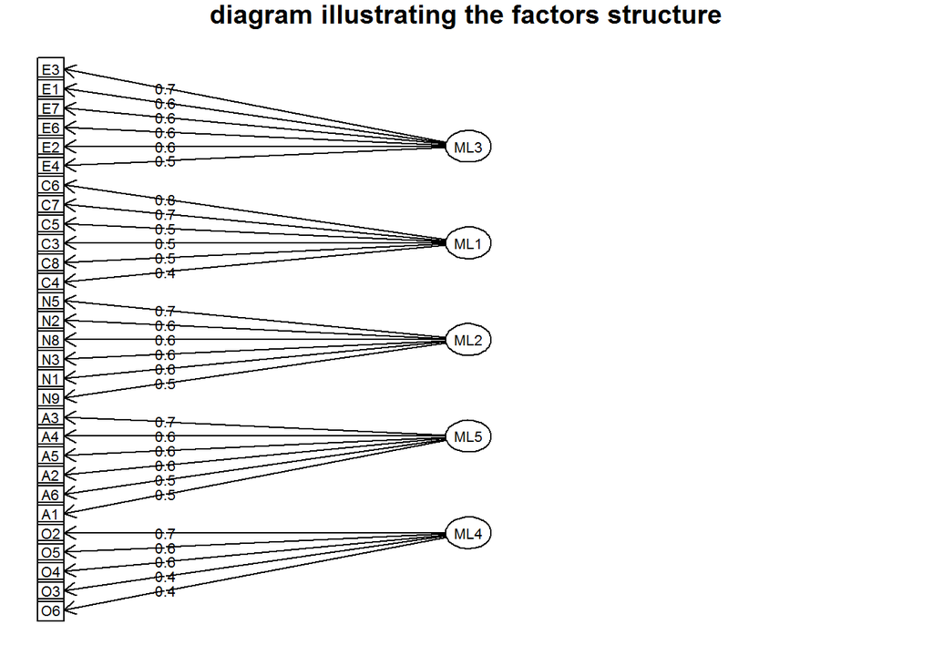

```r
fit<-fa(r = big[,-c(1,2,ncol(big))],nfactors = 5,rotate = "varimax",fm = "ml")
fa.diagram(fit,main = "diagram illustrating the factors structure")
```

```r
load<-fit$loadings%>%matrix(ncol = 5,dimnames = list(c(names(big[,-c(1,2,ncol(big))])),paste0("F",1:5)))%>%round(digits = 3)

load%>%apply(MARGIN = 2,FUN = function(x){
        ifelse(test = x>=.3,yes = x,no = paste(""))
})%>%matrix(ncol = 5,dimnames =list(c(names(big[,-c(1,2,ncol(big))])),paste0("F",1:5)))%>%kable(format = "markdown",digits = 3)
```

|  | F1 | F2 | F3 | F4 | F5 |
| --- | --- | --- | --- | --- | --- |
| E1 | 0.638 |  |  |  |  |
| E2 | 0.555 |  |  |  |  |
| E3 | 0.672 |  |  |  |  |
| E4 | 0.516 |  |  |  |  |
| E6 | 0.569 |  |  |  |  |
| E7 | 0.626 |  |  |  |  |
| N1 |  |  | 0.553 |  |  |
| N2 |  |  | 0.613 |  |  |
| N3 |  |  | 0.581 |  |  |
| N5 |  |  | 0.721 |  |  |
| N8 |  |  | 0.606 |  |  |
| N9 |  |  | 0.51 |  |  |
| A1 |  |  |  | 0.53 |  |
| A2 |  |  |  | 0.576 |  |
| A3 |  |  |  | 0.667 |  |
| A4 |  |  |  | 0.622 |  |
| A5 |  |  |  | 0.61 |  |
| A6 |  |  |  | 0.549 |  |
| O2 |  |  |  |  | 0.724 |
| O3 |  |  |  |  | 0.43 |
| O4 |  |  |  |  | 0.625 |
| O5 |  |  |  |  | 0.635 |
| O6 |  |  |  |  | 0.413 |
| C3 |  | 0.524 |  |  |  |
| C4 |  | 0.402 |  |  |  |
| C5 |  | 0.529 |  |  |  |
| C6 |  | 0.805 |  |  |  |
| C7 |  | 0.721 |  |  |  |
| C8 |  | 0.451 |  |  |  |

Now it is awesome , we have here a great factors structure

So, lets test the reliability of each dimension using alpha

```r
F1<-big%>%select(E1,E2,E3,E4,E6,E7)
F2<-big%>%select(N1,N2,N3,N5,N8,N9)
F3<-big%>%select(A1,A2,A3,A4,A5,A6)
F4<-big%>%select(O2,O3,O4,O5,O6)
F5<-big%>%select(C3,C4,C5,C6,C7,C8)

dimenstions<-list(F1,F2,F3,F4,F5)

alphas<-data.frame(test=alpha(check.keys = T,big%>%select(-c(age_group,Age,Sex)))$total[1],F1=alpha(F1)$total[1],F2=alpha(F2)$total[1],F3=alpha(F3)$total[1],F4=alpha(F4)$total[1],F5=alpha(F5)$total[1])

names(alphas)<-c("All test",paste("F",1:5))
alphas%>%kable(format = "markdown",digits = 2) # table contain row alpha for the all items and every factor
```

| All test | F 1 | F 2 | F 3 | F 4 | F 5 |
| --- | --- | --- | --- | --- | --- |
| 0.86 | 0.79 | 0.78 | 0.79 | 0.75 | 0.81 |

here the alpha values of each factor is roughly good , so we can claim here that the dimensions is reliables

After finishing the EFA lets start in CFA and Confirming the strucure of the model

First of all we have to specify the model

```r
bigmodel<-"
f1=~ E1+E2+E3+E4+E6+E7
f2=~ N1+N2+N3+N5+N8+N9
f3=~ A1+A2+A3+A4+A5+A6
f4=~ O2+O3+O4+O5+O6
f5=~ C3+C4+C5+C6+C7+C8
"
```

After specifying the model we will use `cfa()` function to run the model

```r
bigfit<-cfa(model = bigmodel,data = big%>%select(-c(age_group,Age,Sex)))

summary(bigfit,standardized=T,fit.measures=T)
```

```
## lavaan 0.6-3 ended normally after 52 iterations
##
##   Optimization method                           NLMINB
##   Number of free parameters                         68
##
##   Number of observations                           213
##
##   Estimator                                         ML
##   Model Fit Test Statistic                     619.825
##   Degrees of freedom                               367
##   P-value (Chi-square)                           0.000
##
## Model test baseline model:
##
##   Minimum Function Test Statistic             2294.035
##   Degrees of freedom                               406
##   P-value                                        0.000
##
## User model versus baseline model:
##
##   Comparative Fit Index (CFI)                    0.866
##   Tucker-Lewis Index (TLI)                       0.852
##
## Loglikelihood and Information Criteria:
##
##   Loglikelihood user model (H0)              -7350.547
##   Loglikelihood unrestricted model (H1)      -7040.635
##
##   Number of free parameters                         68
##   Akaike (AIC)                               14837.094
##   Bayesian (BIC)                             15065.662
##   Sample-size adjusted Bayesian (BIC)        14850.190
##
## Root Mean Square Error of Approximation:
##
##   RMSEA                                          0.057
##   90 Percent Confidence Interval          0.049  0.065
##   P-value RMSEA <= 0.05                          0.073
##
## Standardized Root Mean Square Residual:
```

[output cut: 84 more lines]

```
##    .O3                0.769    0.081    9.503    0.000    0.769    0.762
##    .O4                0.498    0.064    7.751    0.000    0.498    0.509
##    .O5                0.371    0.049    7.578    0.000    0.371    0.493
##    .O6                0.665    0.071    9.388    0.000    0.665    0.737
##    .C3                0.608    0.065    9.316    0.000    0.608    0.650
##    .C4                0.587    0.062    9.406    0.000    0.587    0.671
##    .C5                0.474    0.054    8.762    0.000    0.474    0.546
##    .C6                0.441    0.053    8.314    0.000    0.441    0.484
##    .C7                0.294    0.040    7.291    0.000    0.294    0.383
##    .C8                0.566    0.059    9.567    0.000    0.566    0.712
##     f1                0.379    0.074    5.097    0.000    1.000    1.000
##     f2                0.285    0.076    3.770    0.000    1.000    1.000
##     f3                0.196    0.051    3.881    0.000    1.000    1.000
##     f4                0.399    0.079    5.023    0.000    1.000    1.000
##     f5                0.328    0.074    4.404    0.000    1.000    1.000
```

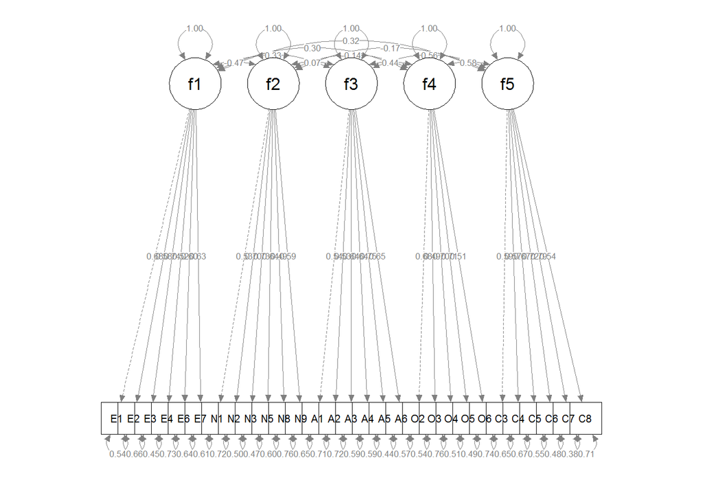

```r
semPaths(bigfit,whatLabels = "std",layout = "tree")
```

The following is the table of all parameters estimated

```r
parameterEstimates(bigfit,standardized = T)%>%kable(digits = 2,format = "markdown")
```

| lhs | op | rhs | est | se | z | pvalue | ci.lower | ci.upper | std.lv | std.all | std.nox |
| --- | --- | --- | --- | --- | --- | --- | --- | --- | --- | --- | --- |
| f1 | =~ | E1 | 1.00 | 0.00 | NA | NA | 1.00 | 1.00 | 0.62 | 0.68 | 0.68 |
| f1 | =~ | E2 | 0.96 | 0.13 | 7.23 | 0.00 | 0.70 | 1.22 | 0.59 | 0.58 | 0.58 |
| f1 | =~ | E3 | 1.19 | 0.14 | 8.75 | 0.00 | 0.92 | 1.45 | 0.73 | 0.74 | 0.74 |
| f1 | =~ | E4 | 0.80 | 0.12 | 6.51 | 0.00 | 0.56 | 1.04 | 0.49 | 0.52 | 0.52 |
| f1 | =~ | E6 | 0.91 | 0.12 | 7.37 | 0.00 | 0.67 | 1.15 | 0.56 | 0.60 | 0.60 |
| f1 | =~ | E7 | 0.91 | 0.12 | 7.69 | 0.00 | 0.68 | 1.14 | 0.56 | 0.63 | 0.63 |
| f2 | =~ | N1 | 1.00 | 0.00 | NA | NA | 1.00 | 1.00 | 0.53 | 0.53 | 0.53 |
| f2 | =~ | N2 | 1.14 | 0.17 | 6.72 | 0.00 | 0.80 | 1.47 | 0.61 | 0.70 | 0.70 |
| f2 | =~ | N3 | 1.17 | 0.17 | 6.83 | 0.00 | 0.84 | 1.51 | 0.63 | 0.73 | 0.73 |
| f2 | =~ | N5 | 1.07 | 0.17 | 6.38 | 0.00 | 0.74 | 1.40 | 0.57 | 0.64 | 0.64 |
| f2 | =~ | N8 | 0.92 | 0.17 | 5.43 | 0.00 | 0.59 | 1.26 | 0.49 | 0.49 | 0.49 |
| f2 | =~ | N9 | 1.10 | 0.18 | 6.12 | 0.00 | 0.75 | 1.45 | 0.59 | 0.59 | 0.59 |
| f3 | =~ | A1 | 1.00 | 0.00 | NA | NA | 1.00 | 1.00 | 0.44 | 0.54 | 0.54 |
| f3 | =~ | A2 | 1.20 | 0.21 | 5.83 | 0.00 | 0.79 | 1.60 | 0.53 | 0.53 | 0.53 |
| f3 | =~ | A3 | 1.22 | 0.19 | 6.58 | 0.00 | 0.86 | 1.58 | 0.54 | 0.64 | 0.64 |
| f3 | =~ | A4 | 1.00 | 0.15 | 6.58 | 0.00 | 0.70 | 1.29 | 0.44 | 0.64 | 0.64 |
| f3 | =~ | A5 | 1.24 | 0.17 | 7.13 | 0.00 | 0.90 | 1.58 | 0.55 | 0.75 | 0.75 |
| f3 | =~ | A6 | 1.22 | 0.18 | 6.65 | 0.00 | 0.86 | 1.58 | 0.54 | 0.65 | 0.65 |
| f4 | =~ | O2 | 1.00 | 0.00 | NA | NA | 1.00 | 1.00 | 0.63 | 0.68 | 0.68 |
| f4 | =~ | O3 | 0.78 | 0.13 | 6.05 | 0.00 | 0.52 | 1.03 | 0.49 | 0.49 | 0.49 |
| f4 | =~ | O4 | 1.10 | 0.13 | 8.13 | 0.00 | 0.83 | 1.36 | 0.69 | 0.70 | 0.70 |
| f4 | =~ | O5 | 0.98 | 0.12 | 8.22 | 0.00 | 0.75 | 1.21 | 0.62 | 0.71 | 0.71 |
| f4 | =~ | O6 | 0.77 | 0.12 | 6.32 | 0.00 | 0.53 | 1.01 | 0.49 | 0.51 | 0.51 |
| f5 | =~ | C3 | 1.00 | 0.00 | NA | NA | 1.00 | 1.00 | 0.57 | 0.59 | 0.59 |
| f5 | =~ | C4 | 0.94 | 0.14 | 6.70 | 0.00 | 0.66 | 1.21 | 0.54 | 0.57 | 0.57 |
| f5 | =~ | C5 | 1.10 | 0.15 | 7.51 | 0.00 | 0.81 | 1.38 | 0.63 | 0.67 | 0.67 |
| f5 | =~ | C6 | 1.20 | 0.15 | 7.83 | 0.00 | 0.90 | 1.50 | 0.68 | 0.72 | 0.72 |
| f5 | =~ | C7 | 1.20 | 0.15 | 8.25 | 0.00 | 0.92 | 1.49 | 0.69 | 0.79 | 0.79 |
| f5 | =~ | C8 | 0.84 | 0.13 | 6.37 | 0.00 | 0.58 | 1.09 | 0.48 | 0.54 | 0.54 |
| E1 | ~~ | E1 | 0.45 | 0.05 | 8.39 | 0.00 | 0.34 | 0.56 | 0.45 | 0.54 | 0.54 |
| E2 | ~~ | E2 | 0.68 | 0.07 | 9.15 | 0.00 | 0.53 | 0.83 | 0.68 | 0.66 | 0.66 |
| E3 | ~~ | E3 | 0.43 | 0.06 | 7.48 | 0.00 | 0.32 | 0.55 | 0.43 | 0.45 | 0.45 |
| E4 | ~~ | E4 | 0.66 | 0.07 | 9.49 | 0.00 | 0.52 | 0.79 | 0.66 | 0.73 | 0.73 |
| E6 | ~~ | E6 | 0.57 | 0.06 | 9.06 | 0.00 | 0.44 | 0.69 | 0.57 | 0.64 | 0.64 |
| E7 | ~~ | E7 | 0.48 | 0.05 | 8.83 | 0.00 | 0.37 | 0.59 | 0.48 | 0.61 | 0.61 |
| N1 | ~~ | N1 | 0.73 | 0.08 | 9.38 | 0.00 | 0.58 | 0.88 | 0.73 | 0.72 | 0.72 |
| N2 | ~~ | N2 | 0.37 | 0.05 | 7.93 | 0.00 | 0.28 | 0.47 | 0.37 | 0.50 | 0.50 |
| N3 | ~~ | N3 | 0.35 | 0.05 | 7.56 | 0.00 | 0.26 | 0.44 | 0.35 | 0.47 | 0.47 |
| N5 | ~~ | N5 | 0.48 | 0.06 | 8.68 | 0.00 | 0.37 | 0.59 | 0.48 | 0.60 | 0.60 |
| N8 | ~~ | N8 | 0.76 | 0.08 | 9.55 | 0.00 | 0.60 | 0.91 | 0.76 | 0.76 | 0.76 |
| N9 | ~~ | N9 | 0.64 | 0.07 | 9.01 | 0.00 | 0.50 | 0.77 | 0.64 | 0.65 | 0.65 |
| A1 | ~~ | A1 | 0.48 | 0.05 | 9.42 | 0.00 | 0.38 | 0.58 | 0.48 | 0.71 | 0.71 |
| A2 | ~~ | A2 | 0.72 | 0.08 | 9.46 | 0.00 | 0.57 | 0.87 | 0.72 | 0.72 | 0.72 |
| A3 | ~~ | A3 | 0.42 | 0.05 | 8.77 | 0.00 | 0.32 | 0.51 | 0.42 | 0.59 | 0.59 |
| A4 | ~~ | A4 | 0.28 | 0.03 | 8.78 | 0.00 | 0.22 | 0.34 | 0.28 | 0.59 | 0.59 |
| A5 | ~~ | A5 | 0.24 | 0.03 | 7.50 | 0.00 | 0.18 | 0.30 | 0.24 | 0.44 | 0.44 |
| A6 | ~~ | A6 | 0.39 | 0.05 | 8.68 | 0.00 | 0.31 | 0.48 | 0.39 | 0.57 | 0.57 |
| O2 | ~~ | O2 | 0.47 | 0.06 | 8.04 | 0.00 | 0.35 | 0.58 | 0.47 | 0.54 | 0.54 |
| O3 | ~~ | O3 | 0.77 | 0.08 | 9.50 | 0.00 | 0.61 | 0.93 | 0.77 | 0.76 | 0.76 |
| O4 | ~~ | O4 | 0.50 | 0.06 | 7.75 | 0.00 | 0.37 | 0.62 | 0.50 | 0.51 | 0.51 |
| O5 | ~~ | O5 | 0.37 | 0.05 | 7.58 | 0.00 | 0.28 | 0.47 | 0.37 | 0.49 | 0.49 |
| O6 | ~~ | O6 | 0.66 | 0.07 | 9.39 | 0.00 | 0.53 | 0.80 | 0.66 | 0.74 | 0.74 |
| C3 | ~~ | C3 | 0.61 | 0.07 | 9.32 | 0.00 | 0.48 | 0.74 | 0.61 | 0.65 | 0.65 |
| C4 | ~~ | C4 | 0.59 | 0.06 | 9.41 | 0.00 | 0.46 | 0.71 | 0.59 | 0.67 | 0.67 |
| C5 | ~~ | C5 | 0.47 | 0.05 | 8.76 | 0.00 | 0.37 | 0.58 | 0.47 | 0.55 | 0.55 |
| C6 | ~~ | C6 | 0.44 | 0.05 | 8.31 | 0.00 | 0.34 | 0.54 | 0.44 | 0.48 | 0.48 |
| C7 | ~~ | C7 | 0.29 | 0.04 | 7.29 | 0.00 | 0.21 | 0.37 | 0.29 | 0.38 | 0.38 |
| C8 | ~~ | C8 | 0.57 | 0.06 | 9.57 | 0.00 | 0.45 | 0.68 | 0.57 | 0.71 | 0.71 |
| f1 | ~~ | f1 | 0.38 | 0.07 | 5.10 | 0.00 | 0.23 | 0.52 | 1.00 | 1.00 | 1.00 |
| f2 | ~~ | f2 | 0.29 | 0.08 | 3.77 | 0.00 | 0.14 | 0.43 | 1.00 | 1.00 | 1.00 |
| f3 | ~~ | f3 | 0.20 | 0.05 | 3.88 | 0.00 | 0.10 | 0.30 | 1.00 | 1.00 | 1.00 |
| f4 | ~~ | f4 | 0.40 | 0.08 | 5.02 | 0.00 | 0.24 | 0.55 | 1.00 | 1.00 | 1.00 |
| f5 | ~~ | f5 | 0.33 | 0.07 | 4.40 | 0.00 | 0.18 | 0.47 | 1.00 | 1.00 | 1.00 |
| f1 | ~~ | f2 | -0.16 | 0.04 | -4.18 | 0.00 | -0.23 | -0.08 | -0.47 | -0.47 | -0.47 |
| f1 | ~~ | f3 | 0.09 | 0.03 | 3.34 | 0.00 | 0.04 | 0.14 | 0.33 | 0.33 | 0.33 |
| f1 | ~~ | f4 | 0.12 | 0.04 | 3.15 | 0.00 | 0.04 | 0.19 | 0.30 | 0.30 | 0.30 |
| f1 | ~~ | f5 | 0.11 | 0.03 | 3.39 | 0.00 | 0.05 | 0.18 | 0.32 | 0.32 | 0.32 |
| f2 | ~~ | f3 | 0.02 | 0.02 | 0.80 | 0.43 | -0.02 | 0.06 | 0.07 | 0.07 | 0.07 |
| f2 | ~~ | f4 | -0.05 | 0.03 | -1.52 | 0.13 | -0.10 | 0.01 | -0.14 | -0.14 | -0.14 |
| f2 | ~~ | f5 | -0.05 | 0.03 | -1.91 | 0.06 | -0.10 | 0.00 | -0.17 | -0.17 | -0.17 |
| f3 | ~~ | f4 | 0.12 | 0.03 | 4.00 | 0.00 | 0.06 | 0.18 | 0.44 | 0.44 | 0.44 |
| f3 | ~~ | f5 | 0.14 | 0.03 | 4.47 | 0.00 | 0.08 | 0.20 | 0.56 | 0.56 | 0.56 |
| f4 | ~~ | f5 | 0.21 | 0.04 | 4.91 | 0.00 | 0.13 | 0.30 | 0.58 | 0.58 | 0.58 |

All Loaings are so good and all of them are significants but we have an issue with the correlation between the factors which supposed to low , but here is so high and significan’t

Now lets look to the measurement fit indecies table

```r
c(fitmeasures(object = bigfit,fit.measures = c("chisq","df","cfi","tli","rmsea","rmsea.ci.upper","rmsea.ci.lower")))%>%round(digits = 2)%>%data.frame()%>%t()%>%kable(format = "markdown")
```

|  | chisq | df | cfi | tli | rmsea | rmsea.ci.upper | rmsea.ci.lower |
| --- | --- | --- | --- | --- | --- | --- | --- |
| . | 619.82 | 367 | 0.87 | 0.85 | 0.06 | 0.06 | 0.05 |

the model has a good measures as *CFI* is moderate as well as *TLI*

but *RMSEA* is very good with Excelent Interval

The only issue in the model is the high correlation of the factors

**Now** Lets try building the model bu **ESEM** Methos and see the difference between it and traditional **CFA**

```r
esemmodel<-vector()

for(i in 1:5){
        esemmodel[i]<-paste0("f",i,"=~",paste0(c(load[,i]),"*",names(load[,1]),collapse = "+"))
}

esemmodel<-paste0(esemmodel,collapse = "\n") #Model Specification

esemfit<-cfa(model = esemmodel,data = big[,-c(1,2,ncol(big))]) #fitting the model

all.fit<-rbind(c(fitmeasures(object = bigfit,fit.measures = c("chisq","df","cfi","tli","rmsea","rmsea.ci.upper","rmsea.ci.lower")))%>%round(digits = 3)%>%data.frame()%>%t(),c(fitmeasures(object = esemfit,fit.measures = c("chisq","df","cfi","tli","rmsea","rmsea.ci.upper","rmsea.ci.lower")))%>%round(digits = 3)%>%data.frame()%>%t())%>%data.frame()

rownames(all.fit)<-c("CFA","ESEM")

all.fit%>%kable(format = "markdown")
```

|  | chisq | df | cfi | tli | rmsea | rmsea.ci.upper | rmsea.ci.lower |
| --- | --- | --- | --- | --- | --- | --- | --- |
| CFA | 619.825 | 367 | 0.866 | 0.852 | 0.057 | 0.065 | 0.049 |
| ESEM | 440.570 | 391 | 0.974 | 0.973 | 0.024 | 0.036 | 0.005 |

SEE !! The fit measures improved alot in case of ESEM method

Now lets look at the correlation between the factors

```r
data.frame(parameterestimates(object = esemfit,standardized = T))[180:189,c(1:4,11)]%>%kable(digits = 3,row.names = F,format = "markdown")
```

| lhs | op | rhs | est | std.all |
| --- | --- | --- | --- | --- |
| f1 | ~~ | f2 | 0.014 | 0.016 |
| f1 | ~~ | f3 | 0.012 | 0.015 |
| f1 | ~~ | f4 | -0.035 | -0.048 |
| f1 | ~~ | f5 | 0.001 | 0.001 |
| f2 | ~~ | f3 | 0.000 | 0.000 |
| f2 | ~~ | f4 | -0.014 | -0.020 |
| f2 | ~~ | f5 | 0.017 | 0.019 |
| f3 | ~~ | f4 | -0.007 | -0.009 |
| f3 | ~~ | f5 | 0.009 | 0.010 |
| f4 | ~~ | f5 | -0.027 | -0.036 |

Here we can find the model match the theory as the factors are uncorrelated !!

**Now** I Think that it is time of exploring the measurement invariance using the two method

## CFA Method

```r
confgfit<-cfa(model = bigmodel,data = big[,-c(1,ncol(big))],group = "Sex") #Configural Invariance

metricfit<-cfa(model = bigmodel,data = big[,-c(1,ncol(big))],group = "Sex",group.equal = "loadings")

scalarfit<-cfa(model = bigmodel,data = big[,-c(1,ncol(big))],group = "Sex",group.equal = c("loadings","intercepts"))

strictfit<-cfa(model = bigmodel,data = big[,-c(1,ncol(big))],group = "Sex",group.equal = c("loadings","intercepts","residuals"))

meanfit<-cfa(model = bigmodel,data = big[,-c(1,ncol(big))],group = "Sex",group.equal = c("loadings","intercepts","residuals","means"))

measurementInvariance(model=bigmodel,data=big[,-c(1,ncol(big))],strict = T,group="Sex")
```

```
##
## Measurement invariance models:
##
## Model 1 : fit.configural
## Model 2 : fit.loadings
## Model 3 : fit.intercepts
## Model 4 : fit.residuals
## Model 5 : fit.means
##
## Chi Square Difference Test
##
##                 Df   AIC   BIC  Chisq Chisq diff Df diff Pr(>Chisq)
## fit.configural 734 14945 15597 1095.8
## fit.loadings   758 14919 15491 1118.2     22.335      24   0.559257
## fit.intercepts 782 14921 15411 1167.3     49.141      24   0.001819 **
## fit.residuals  811 14910 15303 1214.8     47.525      29   0.016454 *
## fit.means      816 14910 15287 1225.2     10.420       5   0.064182 .
## ---
## Signif. codes:  0 '***' 0.001 '**' 0.01 '*' 0.05 '.' 0.1 ' ' 1
##
##
## Fit measures:
##
##                  cfi rmsea cfi.delta rmsea.delta
## fit.configural 0.822 0.068        NA          NA
## fit.loadings   0.822 0.067     0.001       0.001
## fit.intercepts 0.810 0.068     0.012       0.001
## fit.residuals  0.801 0.068     0.009       0.000
## fit.means      0.798 0.069     0.003       0.000
```